# **Projeto de Disciplina - Validação de modelos de clusterização [22E4_3]**

Nathalia de Almeida Castelo Branco

## **Etapa 01 - Infraestrutura**

```python
# Importação das dependências

import numpy as np
import pandas as pd
import matplotlib.pyplot as plt
import seaborn as sns
import datetime

from sklearn.cluster import KMeans, AgglomerativeClustering, DBSCAN
from sklearn.decomposition import PCA
import scipy.cluster.hierarchy as sch
from sklearn.neighbors import NearestNeighbors

from sklearn.metrics import pairwise_distances_argmin_min

from yellowbrick.cluster import KElbowVisualizer
from yellowbrick.cluster import SilhouetteVisualizer

from ds_utils.unsupervised import plot_cluster_cardinality, plot_cluster_magnitude, plot_magnitude_vs_cardinality
from scipy.spatial.distance import euclidean

from DBCV import DBCV

sns.set(style='whitegrid')
```

```python
def plot_cluster_points(df, labels, ax=None, hue="cluster", legend="auto"):
    pca = PCA(2)
    pca_data = pd.DataFrame(pca.fit_transform(df), columns=['PC1','PC2'])
    pca_data['cluster'] = pd.Categorical(labels)
    sns.scatterplot(x="PC1", y="PC2", hue=hue, data=pca_data, ax=ax, legend=legend)
```

## **Etapa 02 - Escolha da base de dados**

1. Escolha uma base de dados para realizar o trabalho. Essa base será usada em um problema de clusterização.

**Dicionário de Dados**

| **FEATURES - CLIENTES** | DESCRIÇÃO | |---|---| | ID | Identificador único do cliente | | Year_Birth | Ano de aniversário do cliente | | Education | Nível de educação do cliente | | Marital_Status | Estado civil do cliente | | Income | Renda anual do cliente | | Kidhome | Número de crianças na casa do cliente | | Teenhome | Número de adolescentes | | Dt_Customer | Data em que se tornou cliente | | Recency | Número de dias desde a última compra | | Complain | Reclamação: se reclamou nos últimos dois anos, 1. Caso contrário, 0. |

| **FEATURES - PRODUTOS** | DESCRIÇÃO | |---|---| | MntWines | Total gasto em vinho, últimos dois anos | | MntFruits | Total gasto em frutas, últimos dois anos | | MntMeatProducts | Total gasto em carnes ou alimentos, últimos dois anos | | MntFishProducts | Total gasto em peixes, últimos dois anos | | MntSweetProducts | Total gasto em doces, últimos dois anos | | MntGoldProds | Total gasto em produtos premium, últimos dois anos |

| **FEATURES - OFERTAS** | DESCRIÇÃO | |---|---| | NumDealsPurchases | Número de pedidos feitos com desconto | | AcceptedCmp1 | Aceite de oferta: se o cliente aceitou a oferta na primeira campanha, 1. Caso contrário, 0. | | AcceptedCmp2 | Aceite de oferta: se o cliente aceitou a oferta na segunda campanha, 1. Caso contrário, 0. | | AcceptedCmp3 | Aceite de oferta: se o cliente aceitou a oferta na terceira campanha, 1. Caso contrário, 0. | | AcceptedCmp4 | Aceite de oferta: se o cliente aceitou a oferta na quarta campanha, 1. Caso contrário, 0. | | AcceptedCmp5 | Aceite de oferta: se o cliente aceitou a oferta na quinta campanha, 1. Caso contrário, 0. | | Response | Aceite de oferta: se o cliente aceitou a oferta na última campanha, 1. Caso contrário, 0. |

| **FEATURES - LOCAL DA COMPRA** | DESCRIÇÃO | |---|---| | NumWebPurchases | Número de compras feitas pelo website | | NumCatalogPurchases | Número de compras feitas usando um catálogo | | NumStorePurchases | Número de compras feitas presencialmente na loja | | NumWebVisitsMonth | Número de visitas ao website da empresa no último mês |

**As colunas Z_CostContact e Z_Revenue não aparentam possuir significado, serão excluídas do estudo**

```python
data = pd.read_csv('data\marketing_campaign.csv', sep=",")
data.head()
```

|  | ID | Year_Birth | Education | Marital_Status | Income | Kidhome | Teenhome | Dt_Customer | Recency | MntWines | ... | NumWebVisitsMonth | AcceptedCmp3 | AcceptedCmp4 | AcceptedCmp5 | AcceptedCmp1 | AcceptedCmp2 | Complain | Z_CostContact | Z_Revenue | Response |
| --- | --- | --- | --- | --- | --- | --- | --- | --- | --- | --- | --- | --- | --- | --- | --- | --- | --- | --- | --- | --- | --- |
| 0 | 5524 | 1957 | Graduation | Single | 58138.0 | 0 | 0 | 04-09-2012 | 58 | 635 | ... | 7 | 0 | 0 | 0 | 0 | 0 | 0 | 3 | 11 | 1 |
| 1 | 2174 | 1954 | Graduation | Single | 46344.0 | 1 | 1 | 08-03-2014 | 38 | 11 | ... | 5 | 0 | 0 | 0 | 0 | 0 | 0 | 3 | 11 | 0 |
| 2 | 4141 | 1965 | Graduation | Together | 71613.0 | 0 | 0 | 21-08-2013 | 26 | 426 | ... | 4 | 0 | 0 | 0 | 0 | 0 | 0 | 3 | 11 | 0 |
| 3 | 6182 | 1984 | Graduation | Together | 26646.0 | 1 | 0 | 10-02-2014 | 26 | 11 | ... | 6 | 0 | 0 | 0 | 0 | 0 | 0 | 3 | 11 | 0 |
| 4 | 5324 | 1981 | PhD | Married | 58293.0 | 1 | 0 | 19-01-2014 | 94 | 173 | ... | 5 | 0 | 0 | 0 | 0 | 0 | 0 | 3 | 11 | 0 |

5 rows × 29 columns

```python
data.info()
```

```
<class 'pandas.core.frame.DataFrame'>
RangeIndex: 2240 entries, 0 to 2239
Data columns (total 29 columns):
 #   Column               Non-Null Count  Dtype
---  ------               --------------  -----
 0   ID                   2240 non-null   int64
 1   Year_Birth           2240 non-null   int64
 2   Education            2240 non-null   object
 3   Marital_Status       2240 non-null   object
 4   Income               2216 non-null   float64
 5   Kidhome              2240 non-null   int64
 6   Teenhome             2240 non-null   int64
 7   Dt_Customer          2240 non-null   object
 8   Recency              2240 non-null   int64
 9   MntWines             2240 non-null   int64
```

[output cut: 21 more lines]

```python
print(data.isnull().sum())
```

```
ID                      0
Year_Birth              0
Education               0
Marital_Status          0
Income                 24
Kidhome                 0
Teenhome                0
Dt_Customer             0
Recency                 0
MntWines                0
MntFruits               0
MntMeatProducts         0
MntFishProducts         0
MntSweetProducts        0
MntGoldProds            0
NumDealsPurchases       0
NumWebPurchases         0
NumCatalogPurchases     0
NumStorePurchases       0
NumWebVisitsMonth       0
AcceptedCmp3            0
AcceptedCmp4            0
AcceptedCmp5            0
AcceptedCmp1            0
AcceptedCmp2            0
Complain                0
Z_CostContact           0
Z_Revenue               0
Response                0
dtype: int64
```

Nota-se que a feature da renda do cliente possui 24 valores nulos. Estes valores serão removidos.

2. Escreva a justificativa para a escolha de dados, dando sua motivação e objetivos.

```
    Esta base de dados foi escolhida com o objetivo de praticar a segmentação de clientes, visto que no momento trabalho na interface entre tecnologia e marketing. A motivação para escolha se baseia em treinar a metodologia de análise de segmentos de clientes e aplicar em um case na empresa em que trabalho.
```

## **Etapa 03 - Mostre através de gráficos a faixa dinâmica das variáveis que serão usadas nas tarefas de clusterização. Analise os resultados mostrados. O que deve ser feito com os dados antes da etapa de clusterização?**

### Demonstração da faixa dinâmica das variáveis

#### Renda familiar anual

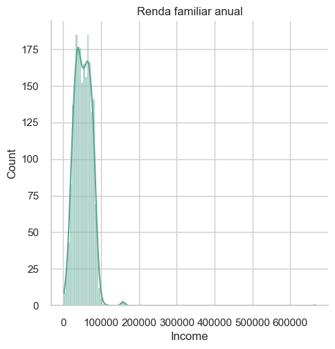

```python
sns.displot(data=data, x = 'Income', color='#59A590', kde=True).set(title=f'Renda familiar anual');
```

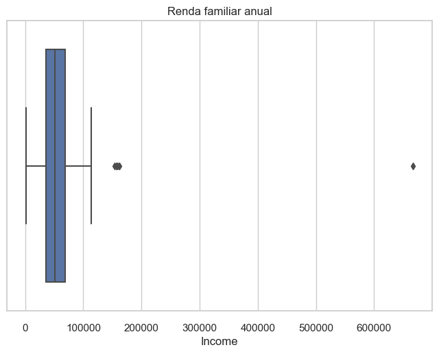

```python
sns.boxplot(x=data['Income']).set(title=f'Renda familiar anual');
```

Para feature **Income**, os pontos próximos de 200 mil são aceitáveis. Já o ponto acima de 600 mil pode ser considerado um outlier.

#### Ano de nascimento

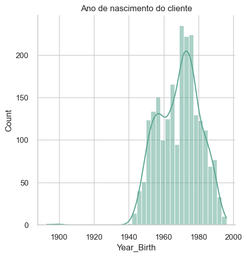

```python
sns.displot(data=data, x = 'Year_Birth', color='#59A590', kde=True).set(title=f'Ano de nascimento do cliente');
```

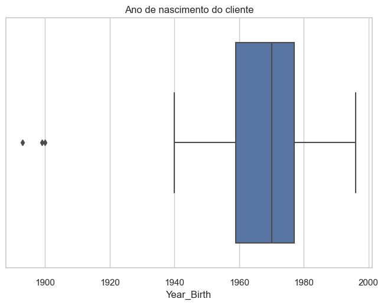

```python
sns.boxplot(x=data['Year_Birth']).set(title=f'Ano de nascimento do cliente');
```

Para a feature **Year_Birth**, os anos antecedentes a 1940 podem ser considerados outliers, visto que, a partir de 1940, os clientes já possuem atualmente 83 anos.

#### Valor gasto em vinho nos últimos 2 anos

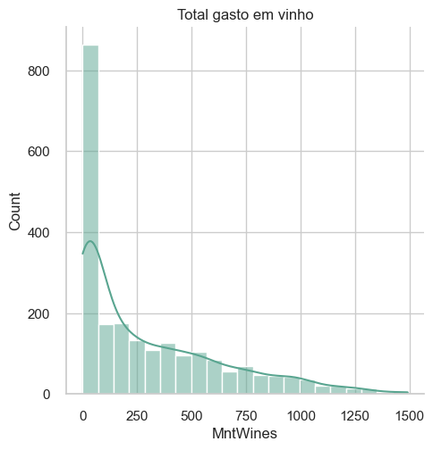

```python
sns.displot(data=data, x = 'MntWines', color='#59A590', kde=True).set(title=f'Total gasto em vinho');
```

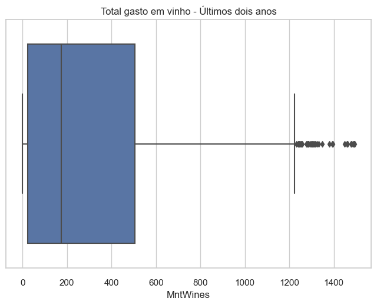

```python
sns.boxplot(x=data['MntWines']).set(title=f'Total gasto em vinho - Últimos dois anos');
```

#### Valor gasto em frutas nos últimos 2 anos

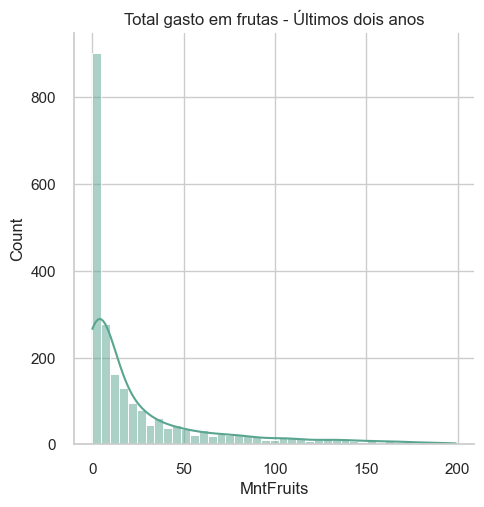

```python
sns.displot(data=data, x = 'MntFruits', color='#59A590', kde=True).set(title=f'Total gasto em frutas - Últimos dois anos');
```

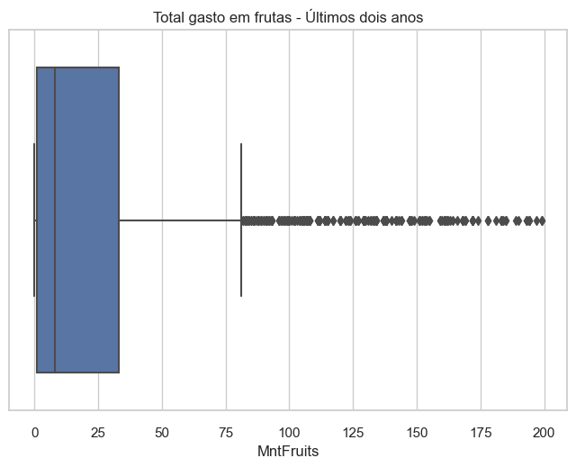

```python
sns.boxplot(x=data['MntFruits']).set(title=f'Total gasto em frutas - Últimos dois anos');
```

#### Valor gasto em carnes/produtos para refeições nos últimos 2 anos

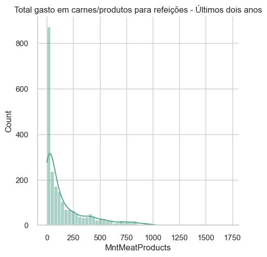

```python
sns.displot(data=data, x = 'MntMeatProducts', color='#59A590', kde=True).set(title=f'Total gasto em carnes/produtos para refeições - Últimos dois anos');
```

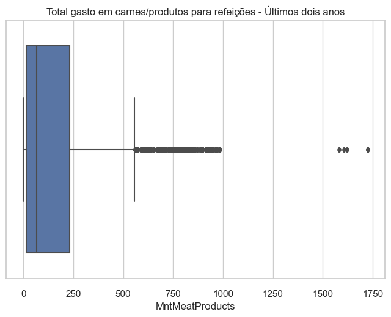

```python
sns.boxplot(x=data['MntMeatProducts']).set(title=f'Total gasto em carnes/produtos para refeições - Últimos dois anos');
```

#### Valor gasto em peixes nos últimos 2 anos

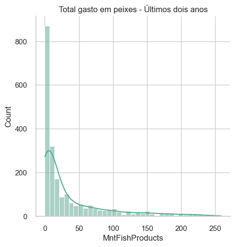

```python
sns.displot(data=data, x = 'MntFishProducts', color='#59A590', kde=True).set(title=f'Total gasto em peixes - Últimos dois anos');
```

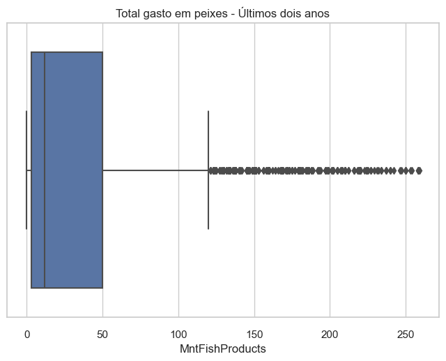

```python
sns.boxplot(x=data['MntFishProducts']).set(title=f'Total gasto em peixes - Últimos dois anos');
```

#### Valor gasto em doces nos últimos 2 anos

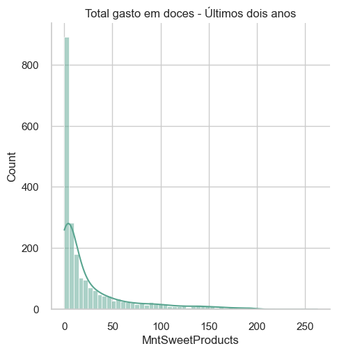

```python
sns.displot(data=data, x = 'MntSweetProducts', color='#59A590', kde=True).set(title=f'Total gasto em doces - Últimos dois anos');
```

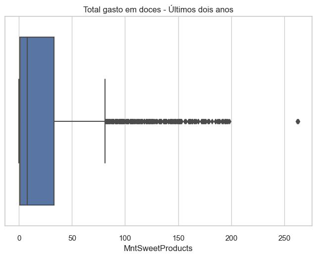

```python
sns.boxplot(x=data['MntSweetProducts']).set(title=f'Total gasto em doces - Últimos dois anos');
```

#### Valor gasto em produtos premium nos últimos 2 anos

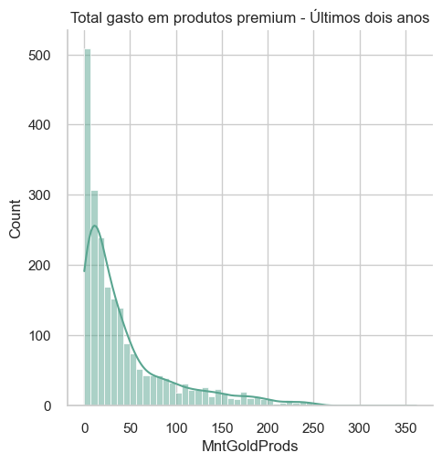

```python
sns.displot(data=data, x = 'MntGoldProds', color='#59A590', kde=True).set(title=f'Total gasto em produtos premium - Últimos dois anos');
```

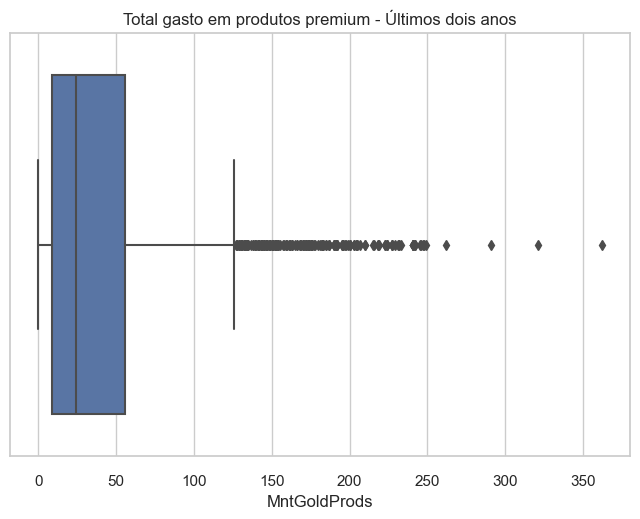

```python
sns.boxplot(x=data['MntGoldProds']).set(title=f'Total gasto em produtos premium - Últimos dois anos');
```

```
A distribuição desta variável é interessante pois é possível observar um comportamento de compra. Em geral, não há grande gasto com produtos premium, mas existe uma série de outliers que aparecem nesta distribuição, representando que existe um mercado para esse consumidor.
```

#### Número de compras pelo website da empresa

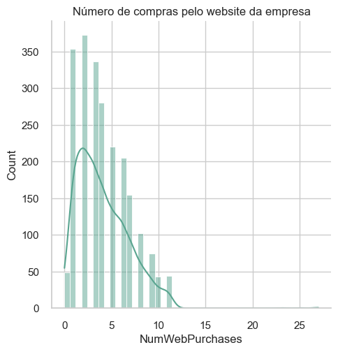

```python
sns.displot(data=data, x = 'NumWebPurchases', color='#59A590', kde=True).set(title=f'Número de compras pelo website da empresa');
```

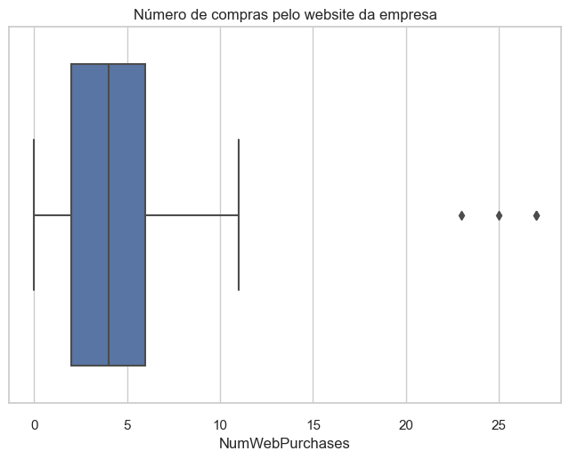

```python
sns.boxplot(x=data['NumWebPurchases']).set(title=f'Número de compras pelo website da empresa');
```

#### Número de visitas ao website da empresa por mês

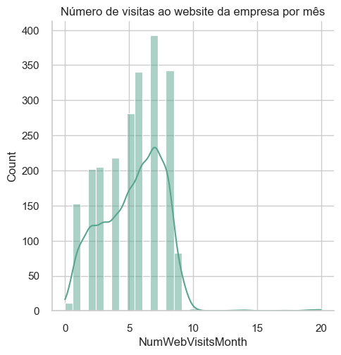

```python
sns.displot(data=data, x = 'NumWebVisitsMonth', color='#59A590', kde=True).set(title=f'Número de visitas ao website da empresa por mês');
```

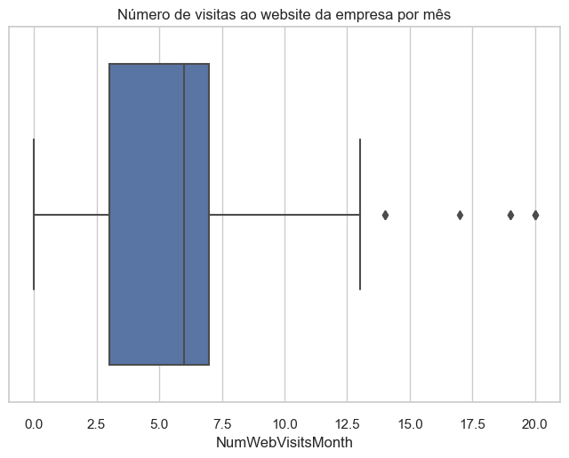

```python
sns.boxplot(x=data['NumWebVisitsMonth']).set(title=f'Número de visitas ao website da empresa por mês');
```

#### Número de compras pelo catálogo da empresa

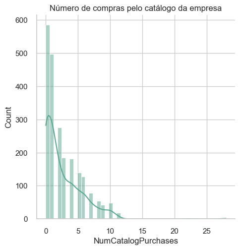

```python
sns.displot(data=data, x = 'NumCatalogPurchases', color='#59A590', kde=True).set(title=f'Número de compras pelo catálogo da empresa');
```

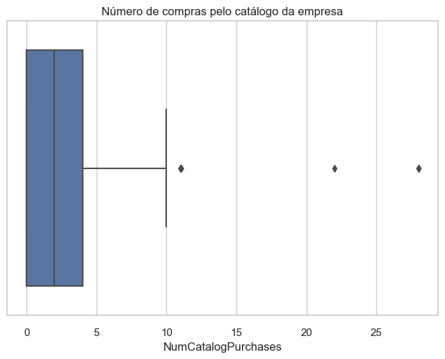

```python
sns.boxplot(x=data['NumCatalogPurchases']).set(title=f'Número de compras pelo catálogo da empresa');
```

#### Número de compras na loja física da empresa

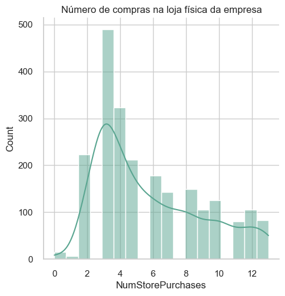

```python
sns.displot(data=data, x = 'NumStorePurchases', color='#59A590', kde=True).set(title=f'Número de compras na loja física da empresa');
```

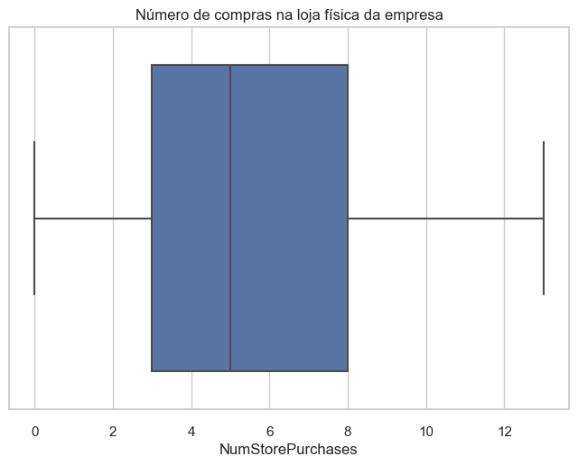

```python
sns.boxplot(x=data['NumStorePurchases']).set(title=f'Número de compras na loja física da empresa');
```

#### Taxa de conversão dos clientes conforme oferta do marketing

```python
clients = data.shape[0]
clients_01 = data['AcceptedCmp1'].value_counts()[1]
clients_02 = data['AcceptedCmp2'].value_counts()[1]
clients_03 = data['AcceptedCmp3'].value_counts()[1]
clients_04 = data['AcceptedCmp4'].value_counts()[1]
clients_05 = data['AcceptedCmp5'].value_counts()[1]
clients_06 = data['Response'].value_counts()[1]
```

```python
print(f'No funil de vendas das campanhas de marketing, estas são as seguintes taxas de conversão: ')
print(f'Para primeira campanha {((clients_01 / clients) * 100):.2f} % aceitam a oferta. ')
print(f'Para segunda campanha {((clients_02 / clients) * 100):.2f} % aceitam a oferta. ')
print(f'Para terceira campanha {((clients_03 / clients) * 100):.2f} % aceitam a oferta. ')
print(f'Para quarta campanha {((clients_04 / clients) * 100):.2f} % aceitam a oferta. ')
print(f'Para quinta campanha {((clients_05 / clients) * 100):.2f} % aceitam a oferta. ')
print(f'Para última campanha {((clients_06 / clients) * 100):.2f} % aceitam a oferta. ')
```

```
No funil de vendas das campanhas de marketing, estas são as seguintes taxas de conversão:
Para primeira campanha 6.43 % aceitam a oferta.
Para segunda campanha 1.34 % aceitam a oferta.
Para terceira campanha 7.28 % aceitam a oferta.
Para quarta campanha 7.46 % aceitam a oferta.
Para quinta campanha 7.28 % aceitam a oferta.
Para última campanha 14.91 % aceitam a oferta.
```

#### Número de pedidos com promoção

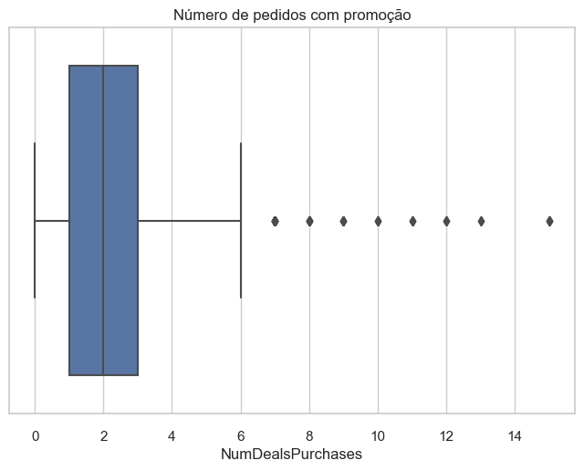

```python
sns.boxplot(x=data['NumDealsPurchases']).set(title=f'Número de pedidos com promoção');
```

[output not shown]

## **Etapa 04 - Realize o pré-processamento adequado dos dados. Descreva os passos necessários.**

```
1. Inicialmente são observadas as features através das suas estatísticas
2. Os valores nulos são removidos
3. É realizada uma breve feature engineering para obtenção da idade do cliente e do número de filhos
4. Após isso, são removidas as features desnecessárias
```

### Exploração dos dados

```python
data.describe().T
```

|  | count | mean | std | min | 25% | 50% | 75% | max |
| --- | --- | --- | --- | --- | --- | --- | --- | --- |
| ID | 2240.0 | 5592.159821 | 3246.662198 | 0.0 | 2828.25 | 5458.5 | 8427.75 | 11191.0 |
| Year_Birth | 2240.0 | 1968.805804 | 11.984069 | 1893.0 | 1959.00 | 1970.0 | 1977.00 | 1996.0 |
| Income | 2216.0 | 52247.251354 | 25173.076661 | 1730.0 | 35303.00 | 51381.5 | 68522.00 | 666666.0 |
| Kidhome | 2240.0 | 0.444196 | 0.538398 | 0.0 | 0.00 | 0.0 | 1.00 | 2.0 |
| Teenhome | 2240.0 | 0.506250 | 0.544538 | 0.0 | 0.00 | 0.0 | 1.00 | 2.0 |
| Recency | 2240.0 | 49.109375 | 28.962453 | 0.0 | 24.00 | 49.0 | 74.00 | 99.0 |
| MntWines | 2240.0 | 303.935714 | 336.597393 | 0.0 | 23.75 | 173.5 | 504.25 | 1493.0 |
| MntFruits | 2240.0 | 26.302232 | 39.773434 | 0.0 | 1.00 | 8.0 | 33.00 | 199.0 |
| MntMeatProducts | 2240.0 | 166.950000 | 225.715373 | 0.0 | 16.00 | 67.0 | 232.00 | 1725.0 |
| MntFishProducts | 2240.0 | 37.525446 | 54.628979 | 0.0 | 3.00 | 12.0 | 50.00 | 259.0 |
| MntSweetProducts | 2240.0 | 27.062946 | 41.280498 | 0.0 | 1.00 | 8.0 | 33.00 | 263.0 |
| MntGoldProds | 2240.0 | 44.021875 | 52.167439 | 0.0 | 9.00 | 24.0 | 56.00 | 362.0 |
| NumDealsPurchases | 2240.0 | 2.325000 | 1.932238 | 0.0 | 1.00 | 2.0 | 3.00 | 15.0 |
| NumWebPurchases | 2240.0 | 4.084821 | 2.778714 | 0.0 | 2.00 | 4.0 | 6.00 | 27.0 |
| NumCatalogPurchases | 2240.0 | 2.662054 | 2.923101 | 0.0 | 0.00 | 2.0 | 4.00 | 28.0 |
| NumStorePurchases | 2240.0 | 5.790179 | 3.250958 | 0.0 | 3.00 | 5.0 | 8.00 | 13.0 |
| NumWebVisitsMonth | 2240.0 | 5.316518 | 2.426645 | 0.0 | 3.00 | 6.0 | 7.00 | 20.0 |
| AcceptedCmp3 | 2240.0 | 0.072768 | 0.259813 | 0.0 | 0.00 | 0.0 | 0.00 | 1.0 |
| AcceptedCmp4 | 2240.0 | 0.074554 | 0.262728 | 0.0 | 0.00 | 0.0 | 0.00 | 1.0 |
| AcceptedCmp5 | 2240.0 | 0.072768 | 0.259813 | 0.0 | 0.00 | 0.0 | 0.00 | 1.0 |
| AcceptedCmp1 | 2240.0 | 0.064286 | 0.245316 | 0.0 | 0.00 | 0.0 | 0.00 | 1.0 |
| AcceptedCmp2 | 2240.0 | 0.013393 | 0.114976 | 0.0 | 0.00 | 0.0 | 0.00 | 1.0 |
| Complain | 2240.0 | 0.009375 | 0.096391 | 0.0 | 0.00 | 0.0 | 0.00 | 1.0 |
| Z_CostContact | 2240.0 | 3.000000 | 0.000000 | 3.0 | 3.00 | 3.0 | 3.00 | 3.0 |
| Z_Revenue | 2240.0 | 11.000000 | 0.000000 | 11.0 | 11.00 | 11.0 | 11.00 | 11.0 |
| Response | 2240.0 | 0.149107 | 0.356274 | 0.0 | 0.00 | 0.0 | 0.00 | 1.0 |

### Remoção de nulos

```python
data = data.dropna()
print(f'O novo número total de clientes únicos observados é de {data.shape[0]} clientes.')
```

```
O novo número total de clientes únicos observados é de 2216 clientes.
```

### Feature Engineering

```python
# Criação da variável idade
date = datetime.date.today()
data['Age'] = date.year - data['Year_Birth']
data.head()
```

|  | ID | Year_Birth | Education | Marital_Status | Income | Kidhome | Teenhome | Dt_Customer | Recency | MntWines | ... | AcceptedCmp3 | AcceptedCmp4 | AcceptedCmp5 | AcceptedCmp1 | AcceptedCmp2 | Complain | Z_CostContact | Z_Revenue | Response | Age |
| --- | --- | --- | --- | --- | --- | --- | --- | --- | --- | --- | --- | --- | --- | --- | --- | --- | --- | --- | --- | --- | --- |
| 0 | 5524 | 1957 | Graduation | Single | 58138.0 | 0 | 0 | 04-09-2012 | 58 | 635 | ... | 0 | 0 | 0 | 0 | 0 | 0 | 3 | 11 | 1 | 66 |
| 1 | 2174 | 1954 | Graduation | Single | 46344.0 | 1 | 1 | 08-03-2014 | 38 | 11 | ... | 0 | 0 | 0 | 0 | 0 | 0 | 3 | 11 | 0 | 69 |
| 2 | 4141 | 1965 | Graduation | Together | 71613.0 | 0 | 0 | 21-08-2013 | 26 | 426 | ... | 0 | 0 | 0 | 0 | 0 | 0 | 3 | 11 | 0 | 58 |
| 3 | 6182 | 1984 | Graduation | Together | 26646.0 | 1 | 0 | 10-02-2014 | 26 | 11 | ... | 0 | 0 | 0 | 0 | 0 | 0 | 3 | 11 | 0 | 39 |
| 4 | 5324 | 1981 | PhD | Married | 58293.0 | 1 | 0 | 19-01-2014 | 94 | 173 | ... | 0 | 0 | 0 | 0 | 0 | 0 | 3 | 11 | 0 | 42 |

5 rows × 30 columns

```python
# Identificar a distribuição do grau de escolaridade
data['Education'].value_counts()
```

```
Graduation    1116
PhD            481
Master         365
2n Cycle       200
Basic           54
Name: Education, dtype: int64
```

```python
# Identificar a distribuição do estado civil
data['Marital_Status'].value_counts()
```

```
Married     857
Together    573
Single      471
Divorced    232
Widow        76
Alone         3
Absurd        2
YOLO          2
Name: Marital_Status, dtype: int64
```

```python
# Condensar o número de filhos em uma variável
data['Children'] = data['Kidhome'] + data['Teenhome']
data.head()
```

|  | ID | Year_Birth | Education | Marital_Status | Income | Kidhome | Teenhome | Dt_Customer | Recency | MntWines | ... | AcceptedCmp4 | AcceptedCmp5 | AcceptedCmp1 | AcceptedCmp2 | Complain | Z_CostContact | Z_Revenue | Response | Age | Children |
| --- | --- | --- | --- | --- | --- | --- | --- | --- | --- | --- | --- | --- | --- | --- | --- | --- | --- | --- | --- | --- | --- |
| 0 | 5524 | 1957 | Graduation | Single | 58138.0 | 0 | 0 | 04-09-2012 | 58 | 635 | ... | 0 | 0 | 0 | 0 | 0 | 3 | 11 | 1 | 66 | 0 |
| 1 | 2174 | 1954 | Graduation | Single | 46344.0 | 1 | 1 | 08-03-2014 | 38 | 11 | ... | 0 | 0 | 0 | 0 | 0 | 3 | 11 | 0 | 69 | 2 |
| 2 | 4141 | 1965 | Graduation | Together | 71613.0 | 0 | 0 | 21-08-2013 | 26 | 426 | ... | 0 | 0 | 0 | 0 | 0 | 3 | 11 | 0 | 58 | 0 |
| 3 | 6182 | 1984 | Graduation | Together | 26646.0 | 1 | 0 | 10-02-2014 | 26 | 11 | ... | 0 | 0 | 0 | 0 | 0 | 3 | 11 | 0 | 39 | 1 |
| 4 | 5324 | 1981 | PhD | Married | 58293.0 | 1 | 0 | 19-01-2014 | 94 | 173 | ... | 0 | 0 | 0 | 0 | 0 | 3 | 11 | 0 | 42 | 1 |

5 rows × 31 columns

### Remoção de outliers

```python
data.describe().T
```

|  | count | mean | std | min | 25% | 50% | 75% | max |
| --- | --- | --- | --- | --- | --- | --- | --- | --- |
| ID | 2216.0 | 5588.353339 | 3249.376275 | 0.0 | 2814.75 | 5458.5 | 8421.75 | 11191.0 |
| Year_Birth | 2216.0 | 1968.820397 | 11.985554 | 1893.0 | 1959.00 | 1970.0 | 1977.00 | 1996.0 |
| Income | 2216.0 | 52247.251354 | 25173.076661 | 1730.0 | 35303.00 | 51381.5 | 68522.00 | 666666.0 |
| Kidhome | 2216.0 | 0.441787 | 0.536896 | 0.0 | 0.00 | 0.0 | 1.00 | 2.0 |
| Teenhome | 2216.0 | 0.505415 | 0.544181 | 0.0 | 0.00 | 0.0 | 1.00 | 2.0 |
| Recency | 2216.0 | 49.012635 | 28.948352 | 0.0 | 24.00 | 49.0 | 74.00 | 99.0 |
| MntWines | 2216.0 | 305.091606 | 337.327920 | 0.0 | 24.00 | 174.5 | 505.00 | 1493.0 |
| MntFruits | 2216.0 | 26.356047 | 39.793917 | 0.0 | 2.00 | 8.0 | 33.00 | 199.0 |
| MntMeatProducts | 2216.0 | 166.995939 | 224.283273 | 0.0 | 16.00 | 68.0 | 232.25 | 1725.0 |
| MntFishProducts | 2216.0 | 37.637635 | 54.752082 | 0.0 | 3.00 | 12.0 | 50.00 | 259.0 |
| MntSweetProducts | 2216.0 | 27.028881 | 41.072046 | 0.0 | 1.00 | 8.0 | 33.00 | 262.0 |
| MntGoldProds | 2216.0 | 43.965253 | 51.815414 | 0.0 | 9.00 | 24.5 | 56.00 | 321.0 |
| NumDealsPurchases | 2216.0 | 2.323556 | 1.923716 | 0.0 | 1.00 | 2.0 | 3.00 | 15.0 |
| NumWebPurchases | 2216.0 | 4.085289 | 2.740951 | 0.0 | 2.00 | 4.0 | 6.00 | 27.0 |
| NumCatalogPurchases | 2216.0 | 2.671029 | 2.926734 | 0.0 | 0.00 | 2.0 | 4.00 | 28.0 |
| NumStorePurchases | 2216.0 | 5.800993 | 3.250785 | 0.0 | 3.00 | 5.0 | 8.00 | 13.0 |
| NumWebVisitsMonth | 2216.0 | 5.319043 | 2.425359 | 0.0 | 3.00 | 6.0 | 7.00 | 20.0 |
| AcceptedCmp3 | 2216.0 | 0.073556 | 0.261106 | 0.0 | 0.00 | 0.0 | 0.00 | 1.0 |
| AcceptedCmp4 | 2216.0 | 0.074007 | 0.261842 | 0.0 | 0.00 | 0.0 | 0.00 | 1.0 |
| AcceptedCmp5 | 2216.0 | 0.073105 | 0.260367 | 0.0 | 0.00 | 0.0 | 0.00 | 1.0 |
| AcceptedCmp1 | 2216.0 | 0.064079 | 0.244950 | 0.0 | 0.00 | 0.0 | 0.00 | 1.0 |
| AcceptedCmp2 | 2216.0 | 0.013538 | 0.115588 | 0.0 | 0.00 | 0.0 | 0.00 | 1.0 |
| Complain | 2216.0 | 0.009477 | 0.096907 | 0.0 | 0.00 | 0.0 | 0.00 | 1.0 |
| Z_CostContact | 2216.0 | 3.000000 | 0.000000 | 3.0 | 3.00 | 3.0 | 3.00 | 3.0 |
| Z_Revenue | 2216.0 | 11.000000 | 0.000000 | 11.0 | 11.00 | 11.0 | 11.00 | 11.0 |
| Response | 2216.0 | 0.150271 | 0.357417 | 0.0 | 0.00 | 0.0 | 0.00 | 1.0 |
| Age | 2216.0 | 54.179603 | 11.985554 | 27.0 | 46.00 | 53.0 | 64.00 | 130.0 |
| Children | 2216.0 | 0.947202 | 0.749062 | 0.0 | 0.00 | 1.0 | 1.00 | 3.0 |

Na descrição estatística dos dados, é possível notar alguns outliers:

- O cliente de maior idade possui 130 anos
- O cliente de maior renda possui a renda muito superior ao quartil 75

Além disso, deve-se remover as features: Z_CostContact e Z_Revenue

```python
# Remoção dos Outliers na Feature "Age" e "Income"
data = data[(data['Age'] < 90)]
data = data[(data['Income'] < 600000)]
print(f'O novo número total de clientes únicos observados é de {data.shape[0]} clientes.')
```

```
O novo número total de clientes únicos observados é de 2212 clientes.
```

### Remoção de features

```python
data.columns
```

```
Index(['ID', 'Year_Birth', 'Education', 'Marital_Status', 'Income', 'Kidhome',
       'Teenhome', 'Dt_Customer', 'Recency', 'MntWines', 'MntFruits',
       'MntMeatProducts', 'MntFishProducts', 'MntSweetProducts',
       'MntGoldProds', 'NumDealsPurchases', 'NumWebPurchases',
       'NumCatalogPurchases', 'NumStorePurchases', 'NumWebVisitsMonth',
       'AcceptedCmp3', 'AcceptedCmp4', 'AcceptedCmp5', 'AcceptedCmp1',
       'AcceptedCmp2', 'Complain', 'Z_CostContact', 'Z_Revenue', 'Response',
       'Age', 'Children'],
      dtype='object')
```

```python
# Remoção das features desnecessárias
data = data.drop(['Kidhome', 'Teenhome', 'Year_Birth', 'Z_CostContact', 'Z_Revenue', 'ID'], axis=1)
```

### Seleção das features para clusterização

```python
data.head()
```

|  | Education | Marital_Status | Income | Dt_Customer | Recency | MntWines | MntFruits | MntMeatProducts | MntFishProducts | MntSweetProducts | ... | NumWebVisitsMonth | AcceptedCmp3 | AcceptedCmp4 | AcceptedCmp5 | AcceptedCmp1 | AcceptedCmp2 | Complain | Response | Age | Children |
| --- | --- | --- | --- | --- | --- | --- | --- | --- | --- | --- | --- | --- | --- | --- | --- | --- | --- | --- | --- | --- | --- |
| 0 | Graduation | Single | 58138.0 | 04-09-2012 | 58 | 635 | 88 | 546 | 172 | 88 | ... | 7 | 0 | 0 | 0 | 0 | 0 | 0 | 1 | 66 | 0 |
| 1 | Graduation | Single | 46344.0 | 08-03-2014 | 38 | 11 | 1 | 6 | 2 | 1 | ... | 5 | 0 | 0 | 0 | 0 | 0 | 0 | 0 | 69 | 2 |
| 2 | Graduation | Together | 71613.0 | 21-08-2013 | 26 | 426 | 49 | 127 | 111 | 21 | ... | 4 | 0 | 0 | 0 | 0 | 0 | 0 | 0 | 58 | 0 |
| 3 | Graduation | Together | 26646.0 | 10-02-2014 | 26 | 11 | 4 | 20 | 10 | 3 | ... | 6 | 0 | 0 | 0 | 0 | 0 | 0 | 0 | 39 | 1 |
| 4 | PhD | Married | 58293.0 | 19-01-2014 | 94 | 173 | 43 | 118 | 46 | 27 | ... | 5 | 0 | 0 | 0 | 0 | 0 | 0 | 0 | 42 | 1 |

5 rows × 25 columns

```python
data.columns
```

```
Index(['Education', 'Marital_Status', 'Income', 'Dt_Customer', 'Recency',
       'MntWines', 'MntFruits', 'MntMeatProducts', 'MntFishProducts',
       'MntSweetProducts', 'MntGoldProds', 'NumDealsPurchases',
       'NumWebPurchases', 'NumCatalogPurchases', 'NumStorePurchases',
       'NumWebVisitsMonth', 'AcceptedCmp3', 'AcceptedCmp4', 'AcceptedCmp5',
       'AcceptedCmp1', 'AcceptedCmp2', 'Complain', 'Response', 'Age',
       'Children'],
      dtype='object')
```

```python
df = data[['Recency','MntWines', 'MntFruits', 'MntMeatProducts', 'MntFishProducts', 'MntSweetProducts', 'MntGoldProds', 'NumDealsPurchases','NumWebPurchases', 'NumCatalogPurchases', 'NumStorePurchases','NumWebVisitsMonth', 'AcceptedCmp3', 'AcceptedCmp4', 'AcceptedCmp5','AcceptedCmp1', 'AcceptedCmp2', 'Complain', 'Response', 'Age','Children']]
```

### Normalização dos dados

```python
# 01 - Normalização dos dados
normalized_data = (df - df.mean()) / df.std()

X = normalized_data.values
```

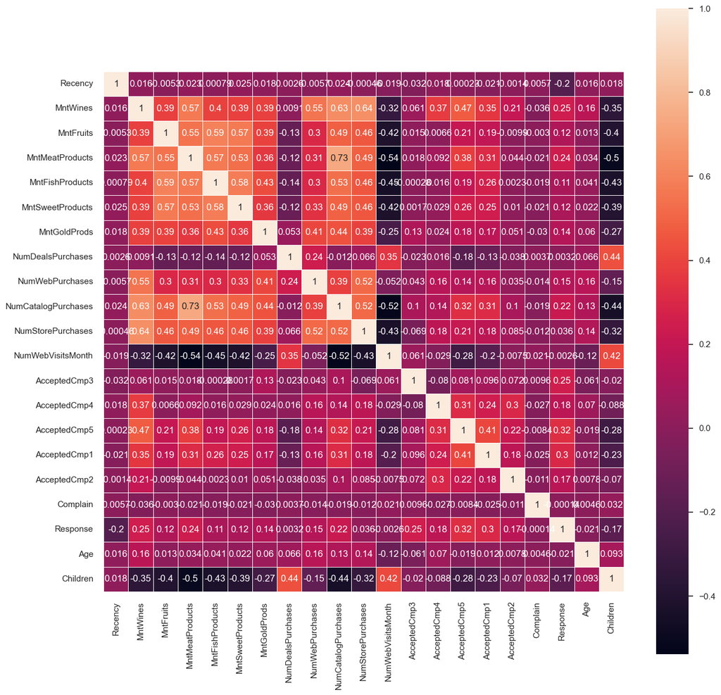

```python
corr = normalized_data.corr()
f, ax = plt.subplots(figsize=(15, 15))
sns.heatmap(corr, square=True, linewidths=.5, annot=True);
```

[output not shown]

## **Etapa 05 - Clusterização**

1. Realizar o agrupamento dos dados, escolhendo o número ótimo de clusters. Para tal, use o índice de silhueta e as técnicas:
- K-Médias
- DBScan

**KMEANS**

```python
seed = 42
k_min = 1
k_max = 15
```

```python
def plot_inertia(df, kmin=k_min, kmax=k_max, figsize=(8, 4)):

    _range = range(kmin, kmax)
    inertias = []
    for k in _range:
        kmeans = KMeans(n_init = 10, n_clusters=k, random_state=seed)
        kmeans.fit(df)
        inertias.append(kmeans.inertia_)

    plt.figure(figsize=figsize)
    plt.plot(_range, inertias, 'bx-')
    plt.xlabel('k')
    plt.ylabel('Inertia')
    plt.show()
```

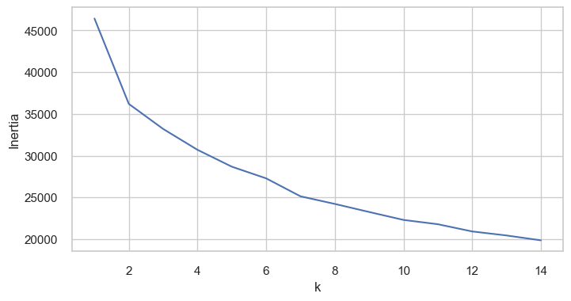

```python
plot_inertia(X);
```

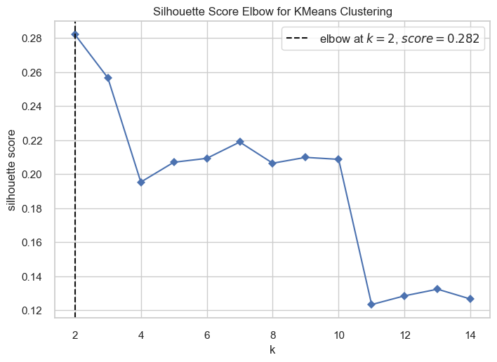

```python
from yellowbrick.cluster import KElbowVisualizer

kmeans = KMeans(n_init = 10, random_state=seed)
visualizer = KElbowVisualizer(
    kmeans, k=(2,15), metric='silhouette', timings=False
)

visualizer.fit(X)
visualizer.show()
```

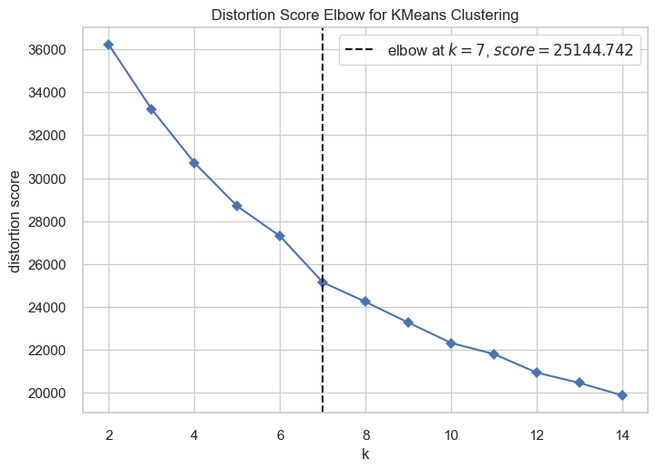

```python
kmeans = KMeans(n_init = 10, random_state=seed)
visualizer = KElbowVisualizer(
    kmeans, k=(2,15), metric='distortion', timings=False
)
visualizer.fit(X)
visualizer.show()
```

**DBSCAN**

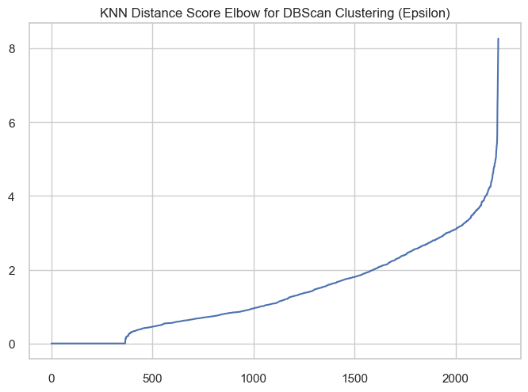

```python
knn = NearestNeighbors(n_neighbors= 12).fit(X)
distances, indices = knn.kneighbors(X)
distances = np.sort(distances, axis=0)[:,1]
plt.title('KNN Distance Score Elbow for DBScan Clustering (Epsilon)')
plt.plot(distances);
```

```python
epsilon = 4.1
min_samples = 20
```

```python
dbscan_model = DBSCAN(eps=epsilon, min_samples= min_samples).fit(X)

no_clusters = len(np.unique(dbscan_model.labels_))
no_noise = np.sum(np.array(dbscan_model.labels_) == -1, axis=0)
```

```python
print(f'DBSCAN encontrou {no_clusters} clusters, com epsilon = {epsilon} e amostra mínima = {min_samples}.')
```

```
DBSCAN encontrou 4 clusters, com epsilon = 4.1 e amostra mínima = 20.
```

Com os resultados em mão, descreva o processo de mensuração do índice de silhueta. Mostre o gráfico e justifique o número de clusters escolhidos.

```
O processo de mensuração do índice de silhueta basicamente funciona assim:
- É uma medida normalizada e varia entre -1 e 1, onde:

   *  1 : perfeição
   *  0 : confusão
   * -1 : erro ou associação errada

A silhueta não é uma boa medida de validação de clusters não convexos.
```

```
Clientes com silhueta menor ou igual a zero devem ser analisados.
```

[output not shown]

2. Compare os dois resultados, aponte as semelhanças e diferenças e interprete.

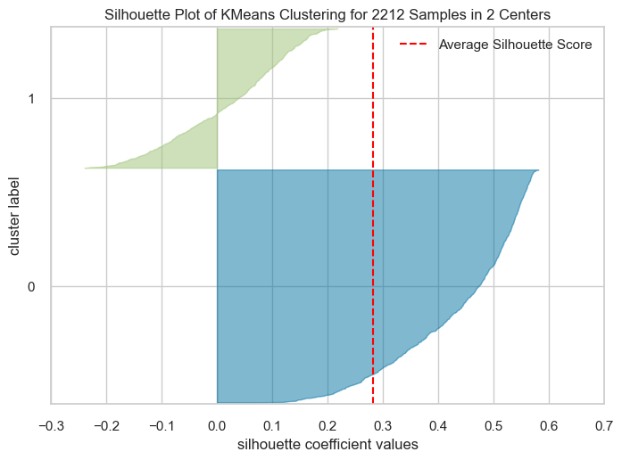

```python
# Plot da silhueta para 2  clusters
visualizer = SilhouetteVisualizer( KMeans(n_clusters = 2, n_init = 10, random_state = seed), colors='yellowbrick')
visualizer.fit(X)
visualizer.show();
```